# Vacancy Rates and Rent Changes

Jens von Bergmann

2017-08-29

This vignette uses the `cmhc` package to download vacancy and rent change data for several areas and visualize them on the same graph to highlight the relationship between the two.

To install and use `cmhc` simply download the repository from Github.

```r
#devtools::install_github("mountainmath/cmhc")
library(cmhc)
```

## Getting the Data

First we read in the data using the `cmhc` package and join the tables we want and tidy up.`cmhc` is preloaded with a list of pre-loaded parameters, `cmhc_geography_list` to access CMHC data for the following cities:

```r
cmhc_geography_list
```

```
$Vancouver
[1] "2410"

$Toronto
[1] "2270"

$Calgary
[1] "0140"

$Victoria
[1] "2440"

$Winnipeg
[1] "2680"
```

The CMHC API is a bit of a mess. `cmhc` uses several internal functions to access data via the CMHC API. The function below makes calls to the CMHC API and returns vacancy and rent price data for a given CMHC city id in a tidy way that we can then use for analysis or graphing.

```r
library(dplyr)
library(tidyr)
# A function to read and tidy CMHC data
vacancy_rent_table_for <- function(geography,geography_type="CMA"){
  region_params=cmhc_region_params(geography = geography,type=geography_type)
  params=cmhc_timeseries_params(table_id = cmhc_table_list["Rms Vacancy Rate Time Seris"],region=region_params)
  dat_vacancy=get_cmhc(params)
  title_x=attr(dat_vacancy,"title")
  dat_vacancy <- dat_vacancy %>%
    select("X1","Total") %>%
    #mutate(Total=as.numeric(as.character(Total))/100) %>%
    rename(vacancy_rate=Total, X=X1)
  params=cmhc_timeseries_params(table_id = cmhc_table_list["Rms Rent Change Time Seris"],region=region_params)
  dat_rent_change=get_cmhc(params)
  title_y=attr(dat_rent_change,"title")
  dat_rent_change <- dat_rent_change %>%
    select("X1","Total") %>%
    #mutate(Total=as.numeric(as.character(Total))/100) %>%
    rename(rent_change=Total, X=X1)
  dat=inner_join(dat_vacancy,dat_rent_change,by="X") %>% rename(Year=X)
  attr(dat,"region")=paste0(geography," ",geography_type)
  attr(dat,"labels")=c(title_x,title_y)
  return(dat)
}
```

Let’s take a look at this data now.

```r
# cmhc_geography_list
cgy <- vacancy_rent_table_for("Calgary")
head(cgy)
```

|  | Year | vacancy_rate | rent_change |
| --- | --- | --- | --- |
| 1 | 1990 October | 2.1 | NA |
| 2 | 1991 October | 3.6 | 2.7 |
| 3 | 1992 October | 5.5 | -0.5 |
| 4 | 1993 October | 5.9 | -1.4 |
| 5 | 1994 October | 5.1 | NA |
| 6 | 1995 October | 3.6 | 0.7 |

```r
tor <- vacancy_rent_table_for("Toronto")
head(tor)
```

|  | Year | vacancy_rate | rent_change |
| --- | --- | --- | --- |
| 1 | 1990 October | 1.0 | NA |
| 2 | 1991 October | 1.8 | 6.3 |
| 3 | 1992 October | 2.2 | 3.9 |
| 4 | 1993 October | 2.0 | 3.6 |
| 5 | 1994 October | 1.3 | 2.4 |
| 6 | 1995 October | 0.8 | 3.3 |

```r
van <- vacancy_rent_table_for("Vancouver")
head(van)
```

|  | Year | vacancy_rate | rent_change |
| --- | --- | --- | --- |
| 1 | 1990 October | 0.9 | NA |
| 2 | 1991 October | 2.2 | 3.3 |
| 3 | 1992 October | 1.6 | 1.8 |
| 4 | 1993 October | 1.1 | 2.6 |
| 5 | 1994 October | 0.8 | 2.6 |
| 6 | 1995 October | 1.2 | 2.6 |

And combine it into a single data frame for comparing directly:

```r
cmhc <- bind_rows(cgy, tor, van, .id = "city")
# Rename id var
cmhc <- cmhc %>%
  # Gather into tidy long format
  gather(key = "Series", value = "Rate",vacancy_rate:rent_change) %>%
  # Tidy up the names and variables
  mutate(city = case_when(
    .$city == 1 ~ "Calgary",
    .$city == 2 ~ "Toronto",
    .$city == 3 ~ "Vancouver"),
    Series = case_when(
    .$Series == "vacancy_rate" ~ "Vacancy Rate",
    .$Series == "rent_change" ~ "Rent Change"),
    #Year = as.numeric(substr(Year,1,4))) %>%
    Year = as.Date(paste0(Year," 01"),format="%Y %B %d"),
    Rate=Rate/100)
```

## Plot the data

With the data all tidy, we can now plot it easily.

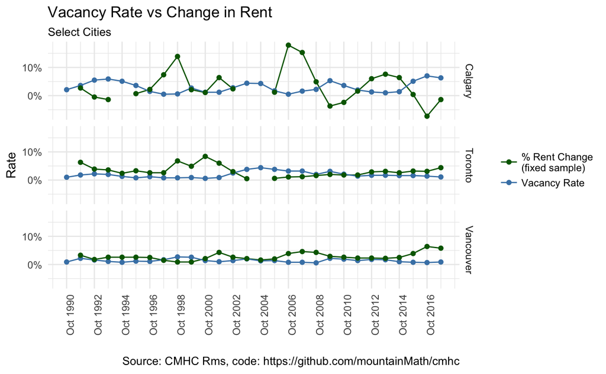

```r
library(ggplot2)
plot_comparison <- ggplot(cmhc, aes(x = Year, y = Rate, color = Series)) +
  geom_line() +
  geom_point() +
  facet_grid(city~.) +
  labs(title="Vacancy Rate vs Change in Rent",
       subtitle ="Select Cities",
       caption="Source: CMHC Rms, code: https://github.com/mountainMath/cmhc") +
  scale_y_continuous(labels = scales::percent) +
  xlab("") +
  scale_x_date(breaks = seq(as.Date("1990-10-01"), as.Date("2017-10-01"), by="2 years"),
    date_labels=format("%b %Y")) +
  scale_color_manual(labels = c("% Rent Change\n(fixed sample)","Vacancy Rate"), values = c("darkgreen", "steelblue"), name = "") +
  theme_minimal() +
  theme(axis.text.x = element_text(angle = 90, hjust = 1))
plot_comparison
ggsave('../images/vacancy_rent_change_cma.png')
```

We can narrow things down by city instead of CMA.

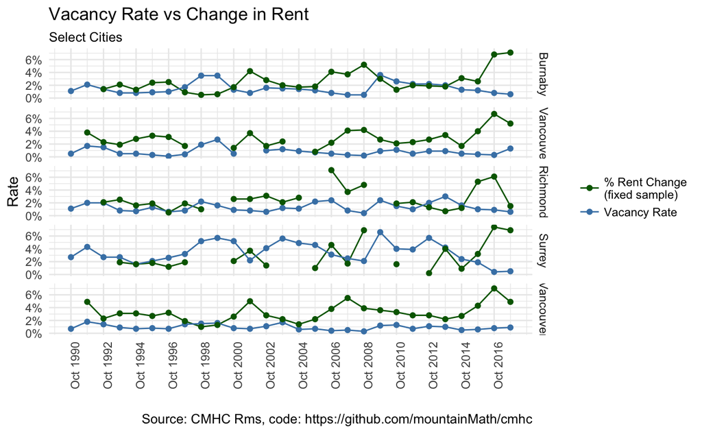

```r
names=c("Vancouver","Burnaby","Richmond","Surrey","North Vancouver (CY)")
cmhc=bind_rows(lapply(names,function(x){return(vacancy_rent_table_for(x,"CSD")) %>% mutate(city=x)}))  %>%
  # Gather into tidy long format
  gather(key = "Series", value = "Rate",vacancy_rate:rent_change) %>%
  # Tidy up the names and variables
  mutate(
    Series = case_when(
    .$Series == "vacancy_rate" ~ "Vacancy Rate",
    .$Series == "rent_change" ~ "Rent Change"),
    Year = as.Date(paste0(Year," 01"),format="%Y %B %d"),
    Rate=Rate/100)
plot_comparison <- ggplot(cmhc, aes(x = Year, y = Rate, color = Series)) +
  geom_line() +
  geom_point() +
  facet_grid(city~.) +
  labs(title="Vacancy Rate vs Change in Rent",
       subtitle ="Select Cities",
       caption="Source: CMHC Rms, code: https://github.com/mountainMath/cmhc") +
  scale_y_continuous(labels = scales::percent) +
  xlab("") +
  scale_x_date(breaks = seq(as.Date("1990-10-01"), as.Date("2017-10-01"), by="2 years"),
    date_labels=format("%b %Y")) +
  scale_color_manual(labels = c("% Rent Change\n(fixed sample)","Vacancy Rate"), values = c("darkgreen", "steelblue"), name = "") +
  theme_minimal() +
  theme(axis.text.x = element_text(angle = 90, hjust = 1))
plot_comparison
ggsave('../images/vacancy_rent_change_csd.png')
```